# DA_project

TeamCC

2024-04-19

```r
library(tidyverse)
library(kableExtra)
library(skimr)
library(gridExtra)
library(factoextra)
library(hopkins)
library(clValid)
library(NbClust)
library(mclust)
```

```r
library(cowplot)
library(dbscan)
library(fpc)
library(corrplot)
library(stats)
library(fmsb)
library(GGally)
library(caret)
library(dplyr)
library(ggrepel)
```

## 1. Dataset Loading and Exploration:

```r
#loading the dataset
cc <- read.csv("C:\\Users\\mansi\\Downloads\\credit_card_dataset.csv",
               header = T,
               row.names = 1)

head(cc)
```

```
##           BALANCE BALANCE_FREQUENCY PURCHASES ONEOFF_PURCHASES
## C10001   40.90075          0.818182     95.40             0.00
## C10002 3202.46742          0.909091      0.00             0.00
## C10003 2495.14886          1.000000    773.17           773.17
## C10004 1666.67054          0.636364   1499.00          1499.00
## C10005  817.71434          1.000000     16.00            16.00
## C10006 1809.82875          1.000000   1333.28             0.00
##        INSTALLMENTS_PURCHASES CASH_ADVANCE PURCHASES_FREQUENCY
## C10001                  95.40        0.000            0.166667
## C10002                   0.00     6442.945            0.000000
## C10003                   0.00        0.000            1.000000
## C10004                   0.00      205.788            0.083333
## C10005                   0.00        0.000            0.083333
## C10006                1333.28        0.000            0.666667
##        ONEOFF_PURCHASES_FREQUENCY PURCHASES_INSTALLMENTS_FREQUENCY
## C10001                   0.000000                         0.083333
## C10002                   0.000000                         0.000000
## C10003                   1.000000                         0.000000
## C10004                   0.083333                         0.000000
## C10005                   0.083333                         0.000000
## C10006                   0.000000                         0.583333
##        CASH_ADVANCE_FREQUENCY CASH_ADVANCE_TRX PURCHASES_TRX CREDIT_LIMIT
## C10001               0.000000                0             2         1000
## C10002               0.250000                4             0         7000
## C10003               0.000000                0            12         7500
## C10004               0.083333                1             1         7500
## C10005               0.000000                0             1         1200
## C10006               0.000000                0             8         1800
##         PAYMENTS MINIMUM_PAYMENTS PRC_FULL_PAYMENT TENURE
## C10001  201.8021         139.5098         0.000000     12
## C10002 4103.0326        1072.3402         0.222222     12
## C10003  622.0667         627.2848         0.000000     12
## C10004    0.0000               NA         0.000000     12
## C10005  678.3348         244.7912         0.000000     12
## C10006 1400.0578        2407.2460         0.000000     12
```

```r
summary(cc)
```

```
##     BALANCE        BALANCE_FREQUENCY   PURCHASES        ONEOFF_PURCHASES
##  Min.   :    0.0   Min.   :0.0000    Min.   :    0.00   Min.   :    0.0
##  1st Qu.:  128.3   1st Qu.:0.8889    1st Qu.:   39.63   1st Qu.:    0.0
##  Median :  873.4   Median :1.0000    Median :  361.28   Median :   38.0
##  Mean   : 1564.5   Mean   :0.8773    Mean   : 1003.20   Mean   :  592.4
##  3rd Qu.: 2054.1   3rd Qu.:1.0000    3rd Qu.: 1110.13   3rd Qu.:  577.4
##  Max.   :19043.1   Max.   :1.0000    Max.   :49039.57   Max.   :40761.2
##
##  INSTALLMENTS_PURCHASES  CASH_ADVANCE     PURCHASES_FREQUENCY
##  Min.   :    0.0        Min.   :    0.0   Min.   :0.00000
##  1st Qu.:    0.0        1st Qu.:    0.0   1st Qu.:0.08333
##  Median :   89.0        Median :    0.0   Median :0.50000
##  Mean   :  411.1        Mean   :  978.9   Mean   :0.49035
##  3rd Qu.:  468.6        3rd Qu.: 1113.8   3rd Qu.:0.91667
##  Max.   :22500.0        Max.   :47137.2   Max.   :1.00000
##
##  ONEOFF_PURCHASES_FREQUENCY PURCHASES_INSTALLMENTS_FREQUENCY
##  Min.   :0.00000            Min.   :0.0000
##  1st Qu.:0.00000            1st Qu.:0.0000
##  Median :0.08333            Median :0.1667
##  Mean   :0.20246            Mean   :0.3644
##  3rd Qu.:0.30000            3rd Qu.:0.7500
##  Max.   :1.00000            Max.   :1.0000
##
##  CASH_ADVANCE_FREQUENCY CASH_ADVANCE_TRX  PURCHASES_TRX     CREDIT_LIMIT
##  Min.   :0.0000         Min.   :  0.000   Min.   :  0.00   Min.   :   50
##  1st Qu.:0.0000         1st Qu.:  0.000   1st Qu.:  1.00   1st Qu.: 1600
##  Median :0.0000         Median :  0.000   Median :  7.00   Median : 3000
##  Mean   :0.1351         Mean   :  3.249   Mean   : 14.71   Mean   : 4494
##  3rd Qu.:0.2222         3rd Qu.:  4.000   3rd Qu.: 17.00   3rd Qu.: 6500
##  Max.   :1.5000         Max.   :123.000   Max.   :358.00   Max.   :30000
##                                                            NA's   :1
##     PAYMENTS       MINIMUM_PAYMENTS   PRC_FULL_PAYMENT     TENURE
##  Min.   :    0.0   Min.   :    0.02   Min.   :0.0000   Min.   : 6.00
##  1st Qu.:  383.3   1st Qu.:  169.12   1st Qu.:0.0000   1st Qu.:12.00
##  Median :  856.9   Median :  312.34   Median :0.0000   Median :12.00
##  Mean   : 1733.1   Mean   :  864.21   Mean   :0.1537   Mean   :11.52
##  3rd Qu.: 1901.1   3rd Qu.:  825.49   3rd Qu.:0.1429   3rd Qu.:12.00
##  Max.   :50721.5   Max.   :76406.21   Max.   :1.0000   Max.   :12.00
##                    NA's   :313
```

```r
names(cc)
```

```
##  [1] "BALANCE"                          "BALANCE_FREQUENCY"
##  [3] "PURCHASES"                        "ONEOFF_PURCHASES"
##  [5] "INSTALLMENTS_PURCHASES"           "CASH_ADVANCE"
##  [7] "PURCHASES_FREQUENCY"              "ONEOFF_PURCHASES_FREQUENCY"
##  [9] "PURCHASES_INSTALLMENTS_FREQUENCY" "CASH_ADVANCE_FREQUENCY"
## [11] "CASH_ADVANCE_TRX"                 "PURCHASES_TRX"
## [13] "CREDIT_LIMIT"                     "PAYMENTS"
## [15] "MINIMUM_PAYMENTS"                 "PRC_FULL_PAYMENT"
## [17] "TENURE"
```

```r
# Create a tibble directly
data <- tibble(
  Variables = c("CUSTID", "BALANCE", "BALANCEFREQUENCY", "PURCHASES", "ONEOFFPURCHASES",
                 "INSTALLMENTSPURCHASES", "CASHADVANCE", "PURCHASESFREQUENCY", "ONEOFFPURCHASESFREQUENCY",
                 "PURCHASESINSTALLMENTSFREQUENCY", "CASHADVANCEFREQUENCY", "CASHADVANCETRX", "PURCHASESTRX",
                 "CREDITLIMIT", "PAYMENTS", "MINIMUM_PAYMENTS", "PRCFULLPAYMENT", "TENURE"),
  Description = c("Identification of Credit Card holder (Categorical)",
                  "Balance amount left in their account to make purchases",
                  "How frequently the Balance is updated, score between 0 and 1 (1 = frequently updated, 0 = not frequently updated)",
                  "Amount of purchases made from account",
                  "Maximum purchase amount done in one-go",
                  "Amount of purchase done in installment",
                  "Cash in advance given by the user",
                  "How frequently the Purchases are being made, score between 0 and 1 (1 = frequently purchased, 0 = not frequently purchased)",
                  "How frequently Purchases are happening in one-go (1 = frequently purchased, 0 = not frequently purchased)",
                  "How frequently purchases in installments are being done (1 = frequently done, 0 = not frequently done)",
                  "How frequently the cash in advance being paid",
                  "Number of Transactions made with Cash in Advanced",
                  "Number of purchase transactions made",
                  "Limit of Credit Card for user",
                  "Amount of Payment done by user",
                  "Minimum amount of payments made by user",
                  "Percent of full payment paid by user",
                  "Tenure of credit card service for user")
)

data %>%
  kbl() %>%
  kable_material_dark()
```

| Variables | Description |
| --- | --- |
| CUSTID | Identification of Credit Card holder (Categorical) |
| BALANCE | Balance amount left in their account to make purchases |
| BALANCEFREQUENCY | How frequently the Balance is updated, score between 0 and 1 (1 = frequently updated, 0 = not frequently updated) |
| PURCHASES | Amount of purchases made from account |
| ONEOFFPURCHASES | Maximum purchase amount done in one-go |
| INSTALLMENTSPURCHASES | Amount of purchase done in installment |
| CASHADVANCE | Cash in advance given by the user |
| PURCHASESFREQUENCY | How frequently the Purchases are being made, score between 0 and 1 (1 = frequently purchased, 0 = not frequently purchased) |
| ONEOFFPURCHASESFREQUENCY | How frequently Purchases are happening in one-go (1 = frequently purchased, 0 = not frequently purchased) |
| PURCHASESINSTALLMENTSFREQUENCY | How frequently purchases in installments are being done (1 = frequently done, 0 = not frequently done) |
| CASHADVANCEFREQUENCY | How frequently the cash in advance being paid |
| CASHADVANCETRX | Number of Transactions made with Cash in Advanced |
| PURCHASESTRX | Number of purchase transactions made |
| CREDITLIMIT | Limit of Credit Card for user |
| PAYMENTS | Amount of Payment done by user |
| MINIMUM_PAYMENTS | Minimum amount of payments made by user |
| PRCFULLPAYMENT | Percent of full payment paid by user |
| TENURE | Tenure of credit card service for user |

- I discovered that the “PURCHASES” variable is just the total of “ONEOFF_PURCHASES” and “INSTALLMENTS_PURCHASES” added together. This might not be super important for our analysis right now, but we’ll look more into it later when we pick which features are most important. So, I’m making a new temporary variable called “MY_PURCHASES” based on 10 rows. It’s basically the same as “PURCHASES,” but I’m adding “ONEOFF_PURCHASES” and “INSTALLMENTS_PURCHASES” together to prove my discovery.

```r
# Select top 10 rows with highest BALANCE
top_10 <- cc %>%
  top_n(10, BALANCE)

# Verify the relationship between PURCHASES, ONEOFF_PURCHASES, and INSTALLMENTS_PURCHASES
top_10 <- top_10 %>%
  mutate(MY_PURCHASES = ONEOFF_PURCHASES + INSTALLMENTS_PURCHASES)

# Display the selected columns and the newly created MY_PURCHASES variable
top_10 %>%
  select(ONEOFF_PURCHASES, INSTALLMENTS_PURCHASES, PURCHASES, MY_PURCHASES) %>%
  kbl() %>%
  kable_material_dark()
```

|  | ONEOFF_PURCHASES | INSTALLMENTS_PURCHASES | PURCHASES | MY_PURCHASES |
| --- | --- | --- | --- | --- |
| C10144 | 9449.07 | 12560.85 | 22009.92 | 22009.92 |
| C10544 | 529.30 | 0.00 | 529.30 | 529.30 |
| C10609 | 7564.81 | 258.93 | 7823.74 | 7823.74 |
| C10914 | 0.00 | 0.00 | 0.00 | 0.00 |
| C12434 | 0.00 | 1168.75 | 1168.75 | 1168.75 |
| C14256 | 3657.30 | 1630.98 | 5288.28 | 5288.28 |
| C14836 | 717.24 | 0.00 | 717.24 | 717.24 |
| C15429 | 105.30 | 579.44 | 684.74 | 684.74 |
| C15642 | 0.00 | 1770.57 | 1770.57 | 1770.57 |
| C16812 | 3582.45 | 1442.23 | 5024.68 | 5024.68 |

```r
# Missing Value Check
colSums(is.na(cc)) %>%
  kbl(col.names = "Numbers of Missing Values") %>%
  kable_material_dark(full_width = F)
```

|  | Numbers of Missing Values |
| --- | --- |
| BALANCE | 0 |
| BALANCE_FREQUENCY | 0 |
| PURCHASES | 0 |
| ONEOFF_PURCHASES | 0 |
| INSTALLMENTS_PURCHASES | 0 |
| CASH_ADVANCE | 0 |
| PURCHASES_FREQUENCY | 0 |
| ONEOFF_PURCHASES_FREQUENCY | 0 |
| PURCHASES_INSTALLMENTS_FREQUENCY | 0 |
| CASH_ADVANCE_FREQUENCY | 0 |
| CASH_ADVANCE_TRX | 0 |
| PURCHASES_TRX | 0 |
| CREDIT_LIMIT | 1 |
| PAYMENTS | 0 |
| MINIMUM_PAYMENTS | 313 |
| PRC_FULL_PAYMENT | 0 |
| TENURE | 0 |

```r
summary(cc) %>% kbl() %>% kable_material_dark()
```

|  | BALANCE | BALANCE_FREQUENCY | PURCHASES | ONEOFF_PURCHASES | INSTALLMENTS_PURCHASES | CASH_ADVANCE | PURCHASES_FREQUENCY | ONEOFF_PURCHASES_FREQUENCY | PURCHASES_INSTALLMENTS_FREQUENCY | CASH_ADVANCE_FREQUENCY | CASH_ADVANCE_TRX | PURCHASES_TRX | CREDIT_LIMIT | PAYMENTS | MINIMUM_PAYMENTS | PRC_FULL_PAYMENT | TENURE |
| --- | --- | --- | --- | --- | --- | --- | --- | --- | --- | --- | --- | --- | --- | --- | --- | --- | --- |
|  | Min. : 0.0 | Min. :0.0000 | Min. : 0.00 | Min. : 0.0 | Min. : 0.0 | Min. : 0.0 | Min. :0.00000 | Min. :0.00000 | Min. :0.0000 | Min. :0.0000 | Min. : 0.000 | Min. : 0.00 | Min. : 50 | Min. : 0.0 | Min. : 0.02 | Min. :0.0000 | Min. : 6.00 |
|  | 1st Qu.: 128.3 | 1st Qu.:0.8889 | 1st Qu.: 39.63 | 1st Qu.: 0.0 | 1st Qu.: 0.0 | 1st Qu.: 0.0 | 1st Qu.:0.08333 | 1st Qu.:0.00000 | 1st Qu.:0.0000 | 1st Qu.:0.0000 | 1st Qu.: 0.000 | 1st Qu.: 1.00 | 1st Qu.: 1600 | 1st Qu.: 383.3 | 1st Qu.: 169.12 | 1st Qu.:0.0000 | 1st Qu.:12.00 |
|  | Median : 873.4 | Median :1.0000 | Median : 361.28 | Median : 38.0 | Median : 89.0 | Median : 0.0 | Median :0.50000 | Median :0.08333 | Median :0.1667 | Median :0.0000 | Median : 0.000 | Median : 7.00 | Median : 3000 | Median : 856.9 | Median : 312.34 | Median :0.0000 | Median :12.00 |
|  | Mean : 1564.5 | Mean :0.8773 | Mean : 1003.20 | Mean : 592.4 | Mean : 411.1 | Mean : 978.9 | Mean :0.49035 | Mean :0.20246 | Mean :0.3644 | Mean :0.1351 | Mean : 3.249 | Mean : 14.71 | Mean : 4494 | Mean : 1733.1 | Mean : 864.21 | Mean :0.1537 | Mean :11.52 |
|  | 3rd Qu.: 2054.1 | 3rd Qu.:1.0000 | 3rd Qu.: 1110.13 | 3rd Qu.: 577.4 | 3rd Qu.: 468.6 | 3rd Qu.: 1113.8 | 3rd Qu.:0.91667 | 3rd Qu.:0.30000 | 3rd Qu.:0.7500 | 3rd Qu.:0.2222 | 3rd Qu.: 4.000 | 3rd Qu.: 17.00 | 3rd Qu.: 6500 | 3rd Qu.: 1901.1 | 3rd Qu.: 825.49 | 3rd Qu.:0.1429 | 3rd Qu.:12.00 |
|  | Max. :19043.1 | Max. :1.0000 | Max. :49039.57 | Max. :40761.2 | Max. :22500.0 | Max. :47137.2 | Max. :1.00000 | Max. :1.00000 | Max. :1.0000 | Max. :1.5000 | Max. :123.000 | Max. :358.00 | Max. :30000 | Max. :50721.5 | Max. :76406.21 | Max. :1.0000 | Max. :12.00 |
|  | NA | NA | NA | NA | NA | NA | NA | NA | NA | NA | NA | NA | NA’s :1 | NA | NA’s :313 | NA | NA |

- Based on the summary after exploring the dataset, this is what we plan to do next: We have a dataset with 8950 rows of data. Even after removing the missing values, we’ll still have about 96.5% of our data left. Normally, when we have missing values, there are different ways to deal with them. We can remove them, or replace them with the average or middle value of the other data. There are also more complex methods like using special algorithms to guess what the missing values might be, like KNN or bagging algorithms. We usually use these methods when there are a lot of missing values in important parts of the data. For example, if more than 5% but less than 60% of a variable’s values are missing. But, since our missing data is below 5%, we choose to remove them for our project.

## 2. Dataset Cleaning and Manipulation:

```r
# Display original variable names
cc_original_names <- colnames(cc) %>%
  as.data.frame() %>%
  rename(Variables = '.') %>%
  kbl() %>%
  kable_material_dark()

print(cc_original_names)
```

[output not shown]

```r
# Transform variable names to reader-friendly form
cc <- cc %>%
  rename_all(str_to_title)

# Display transformed variable names
cc_transformed_names <- colnames(cc) %>%
  as.data.frame() %>%
  rename(Variables = '.') %>%
  kbl() %>%
  kable_material_dark()

print(cc_transformed_names)
```

[output not shown]

```r
# Remove missing values
cc <- na.omit(cc)

# Display updated number of rows
nrow_cc <- nrow(cc)

print(nrow_cc)
```

```
## [1] 8636
```

As part of data cleaning and manipulation:

- Original Variable Names Displayed: Initially, the original variable names, which were in all capital letters, were displayed to provide insight into the dataset structure.
- Transformation of Variable Names: The variable names were transformed into a more reader-friendly form using the str_to_title function. This step aimed to enhance readability and comprehension of the dataset.
- Missing Values Removal: Missing values were removed from the dataset using the na.omit() function. This ensured that only complete cases were retained for subsequent analysis.
- Updated Dataset Size: After removing missing values, the number of rows in the dataset was updated to reflect the reduction in size. The updated dataset now contains a total of 8636 rows.

## 3. Exploratory Data Analysis (EDA):

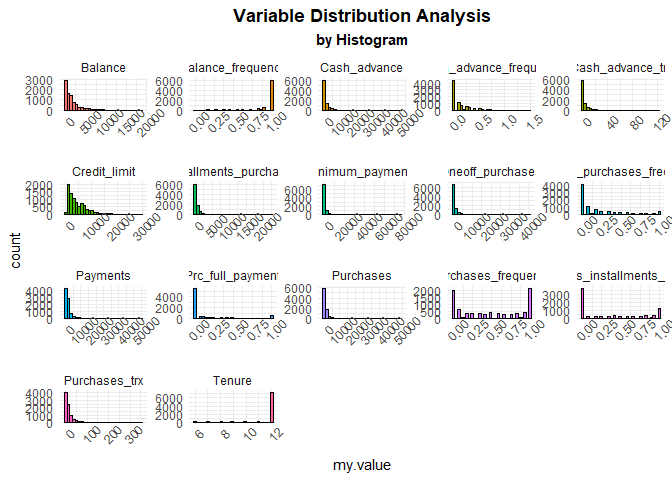

```r
#A histogram is plotted to investigate the distribution of the data

# Data frame transformation
df_long <- cc %>%
  pivot_longer(cols = 1:17, names_to = "my.variable", values_to = "my.value")

# Histogram plot
ggplot(df_long, aes(x = my.value, fill = my.variable)) +
  geom_histogram(color = "black") +
  facet_wrap(~my.variable, scale = "free") +
  theme_minimal() +
  theme(legend.position = "none",
        axis.text.x = element_text(angle = 45),
        plot.title = element_text(face = "bold", hjust = 0.5),
        plot.subtitle = element_text(face = "bold", hjust = 0.5)) +
  labs(title = "Variable Distribution Analysis",
       subtitle = "by Histogram")
```

- Several columns in the dataset exhibit skewness and contain large values. Typically, one might apply a logarithmic transformation to such variables to normalize their distribution. However, since I intend to standardize these variables in a subsequent section, I will refrain from log-transforming them at this stage.

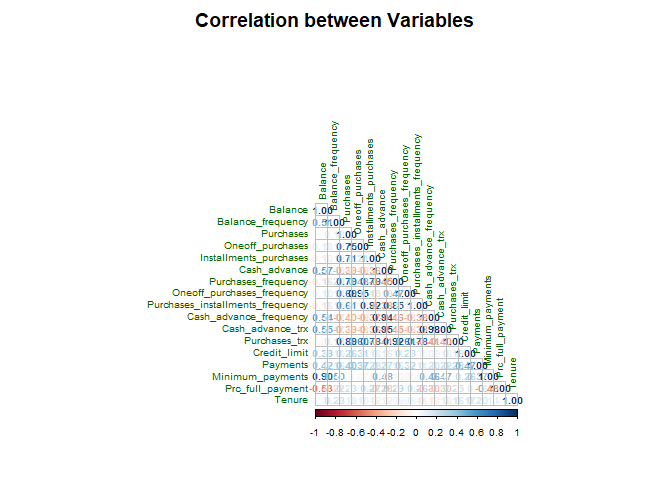

```r
# Compute the correlation matrix
corr_cc <- cor(cc, method = "spearman")

# Plot the correlation matrix
corrplot(corr_cc, type = "lower", method = "number",
         tl.cex = 0.6, tl.col = "darkgreen", number.cex = 0.6, pch = 20,
         title = "Correlation between Variables",
         addrect = 8, rect.col = "red",
         cl.pos = "b", cl.cex = 0.6,
         mar = c(2, 2, 2, 2))
```

```r
# Construct correlation table
cor_cc_df <- round(cor(corr_cc), 2) %>%
  as.data.frame()

# Display correlation table
cor_cc_df %>%
  kbl() %>%
  kable_material_dark()
```

|  | Balance | Balance_frequency | Purchases | Oneoff_purchases | Installments_purchases | Cash_advance | Purchases_frequency | Oneoff_purchases_frequency | Purchases_installments_frequency | Cash_advance_frequency | Cash_advance_trx | Purchases_trx | Credit_limit | Payments | Minimum_payments | Prc_full_payment | Tenure |
| --- | --- | --- | --- | --- | --- | --- | --- | --- | --- | --- | --- | --- | --- | --- | --- | --- | --- |
| Balance | 1.00 | 0.60 | -0.65 | -0.35 | -0.72 | 0.81 | -0.74 | -0.38 | -0.72 | 0.80 | 0.80 | -0.70 | 0.31 | 0.32 | 0.99 | -0.93 | -0.17 |
| Balance_frequency | 0.60 | 1.00 | -0.21 | -0.14 | -0.19 | 0.21 | -0.17 | -0.13 | -0.16 | 0.23 | 0.23 | -0.17 | -0.03 | -0.04 | 0.65 | -0.63 | 0.16 |
| Purchases | -0.65 | -0.21 | 1.00 | 0.83 | 0.88 | -0.92 | 0.95 | 0.83 | 0.84 | -0.92 | -0.92 | 0.98 | 0.07 | 0.10 | -0.63 | 0.58 | 0.18 |
| Oneoff_purchases | -0.35 | -0.14 | 0.83 | 1.00 | 0.47 | -0.65 | 0.64 | 1.00 | 0.41 | -0.65 | -0.65 | 0.73 | 0.27 | 0.27 | -0.38 | 0.29 | 0.11 |
| Installments_purchases | -0.72 | -0.19 | 0.88 | 0.47 | 1.00 | -0.89 | 0.96 | 0.47 | 0.99 | -0.89 | -0.90 | 0.94 | -0.13 | -0.10 | -0.66 | 0.64 | 0.18 |
| Cash_advance | 0.81 | 0.21 | -0.92 | -0.65 | -0.89 | 1.00 | -0.94 | -0.66 | -0.88 | 1.00 | 1.00 | -0.94 | 0.08 | 0.13 | 0.76 | -0.73 | -0.37 |
| Purchases_frequency | -0.74 | -0.17 | 0.95 | 0.64 | 0.96 | -0.94 | 1.00 | 0.65 | 0.96 | -0.94 | -0.94 | 0.99 | -0.11 | -0.12 | -0.69 | 0.64 | 0.18 |
| Oneoff_purchases_frequency | -0.38 | -0.13 | 0.83 | 1.00 | 0.47 | -0.66 | 0.65 | 1.00 | 0.42 | -0.66 | -0.66 | 0.74 | 0.24 | 0.23 | -0.40 | 0.31 | 0.11 |
| Purchases_installments_frequency | -0.72 | -0.16 | 0.84 | 0.41 | 0.99 | -0.88 | 0.96 | 0.42 | 1.00 | -0.88 | -0.88 | 0.92 | -0.19 | -0.19 | -0.66 | 0.63 | 0.18 |
| Cash_advance_frequency | 0.80 | 0.23 | -0.92 | -0.65 | -0.89 | 1.00 | -0.94 | -0.66 | -0.88 | 1.00 | 1.00 | -0.94 | 0.03 | 0.09 | 0.75 | -0.74 | -0.38 |
| Cash_advance_trx | 0.80 | 0.23 | -0.92 | -0.65 | -0.90 | 1.00 | -0.94 | -0.66 | -0.88 | 1.00 | 1.00 | -0.94 | 0.03 | 0.10 | 0.75 | -0.74 | -0.37 |
| Purchases_trx | -0.70 | -0.17 | 0.98 | 0.73 | 0.94 | -0.94 | 0.99 | 0.74 | 0.92 | -0.94 | -0.94 | 1.00 | -0.04 | -0.03 | -0.66 | 0.61 | 0.20 |
| Credit_limit | 0.31 | -0.03 | 0.07 | 0.27 | -0.13 | 0.08 | -0.11 | 0.24 | -0.19 | 0.03 | 0.03 | -0.04 | 1.00 | 0.62 | 0.24 | -0.18 | 0.09 |
| Payments | 0.32 | -0.04 | 0.10 | 0.27 | -0.10 | 0.13 | -0.12 | 0.23 | -0.19 | 0.09 | 0.10 | -0.03 | 0.62 | 1.00 | 0.28 | -0.10 | 0.03 |
| Minimum_payments | 0.99 | 0.65 | -0.63 | -0.38 | -0.66 | 0.76 | -0.69 | -0.40 | -0.66 | 0.75 | 0.75 | -0.66 | 0.24 | 0.28 | 1.00 | -0.93 | -0.10 |
| Prc_full_payment | -0.93 | -0.63 | 0.58 | 0.29 | 0.64 | -0.73 | 0.64 | 0.31 | 0.63 | -0.74 | -0.74 | 0.61 | -0.18 | -0.10 | -0.93 | 1.00 | 0.08 |
| Tenure | -0.17 | 0.16 | 0.18 | 0.11 | 0.18 | -0.37 | 0.18 | 0.11 | 0.18 | -0.38 | -0.37 | 0.20 | 0.09 | 0.03 | -0.10 | 0.08 | 1.00 |

```r
# Find highly correlated variables
correlated_vars <- caret::findCorrelation(x = corr_cc,
                                          names = TRUE,  # Display variable names
                                          cutoff = 0.80)

# Display redundant variables
correlated_vars_df <- correlated_vars %>%
  as.data.frame() %>%
  rename(`Redundant Variables` = '.')

correlated_vars_df %>%
  kbl(col.names = "Redundant Variables") %>%
  kable_styling(full_width = FALSE)
```

| Redundant Variables |
| --- |
| Purchases_trx |
| Purchases_frequency |
| Cash_advance |
| Cash_advance_frequency |
| Installments_purchases |
| Balance |
| Oneoff_purchases |

```r
# Update the dataset by removing correlated variables
cc <- cc %>%
  select(-one_of(correlated_vars))

# Display active variables
active_vars_df <- colnames(cc) %>%
  as.data.frame() %>%
  rename(`Active Variables` = '.')

active_vars_df %>%
  kbl(col.names = "Active Variables") %>%
  kable_styling(full_width = FALSE)
```

| Active Variables |
| --- |
| Balance_frequency |
| Purchases |
| Oneoff_purchases_frequency |
| Purchases_installments_frequency |
| Cash_advance_trx |
| Credit_limit |
| Payments |
| Minimum_payments |
| Prc_full_payment |
| Tenure |

- We have successfully reduced the total number of variables in the dataset from 17 to just 10 by eliminating 7 highly correlated variables.
- Thus, as part of the Exploratory Data Analysis (EDA) phase, we began by visualizing the distribution of our data using histograms, allowing us to gain insights into its spread and central tendencies. Following this, we conducted a Correlation Check to identify relationships between variables. Any correlated variables, indicating redundancy, were flagged for removal. We employed a threshold of 0.8 for correlation values, beyond which variables were considered highly correlated. As a result, the dataset’s total variable count was reduced from 17 to 10, with seven highly correlated variables removed. This streamlined dataset will facilitate more focused and efficient analysis moving forward.

## 4. Feature Selection and Dimensionality Reduction:

In this section, we are utilizing *Principal Component Analysis (PCA)* to explore data.

- Before diving into PCA, we standardize our data to make comparisons fair, ensuring all variables are on the same scale.

```r
# Scale the data
cc.scale <- scale(cc)
head(cc.scale) %>% kbl() %>% kable_material_dark()
```

|  | Balance_frequency | Purchases | Oneoff_purchases_frequency | Purchases_installments_frequency | Cash_advance_trx | Credit_limit | Payments | Minimum_payments | Prc_full_payment | Tenure |
| --- | --- | --- | --- | --- | --- | --- | --- | --- | --- | --- |
| C10001 | -0.3700254 | -0.4291590 | -0.6862398 | -0.7171374 | -0.4794091 | -0.9625197 | -0.5439104 | -0.3054899 | -0.5376958 | 0.3551601 |
| C10002 | 0.0676750 | -0.4731808 | -0.6862398 | -0.9264679 | 0.0992522 | 0.6771649 | 0.7968061 | 0.0876836 | 0.2123677 | 0.3551601 |
| C10003 | 0.5053754 | -0.1164058 | 2.6464980 | -0.9264679 | -0.4794091 | 0.8138052 | -0.3994801 | -0.0999003 | -0.5376958 | 0.3551601 |
| C10005 | 0.5053754 | -0.4657977 | -0.4085128 | -0.9264679 | -0.4794091 | -0.9078636 | -0.3801428 | -0.2611154 | -0.5376958 | 0.3551601 |
| C10006 | 0.5053754 | 0.1420539 | -0.6862398 | 0.5388507 | -0.4794091 | -0.7438951 | -0.1321118 | 0.6503258 | -0.5376958 | 0.3551601 |
| C10007 | 0.5053754 | 2.7989266 | 2.6464980 | 1.5855083 | -0.4794091 | 2.4534898 | 1.5704929 | -0.2808094 | 2.8375934 | 0.3551601 |

```r
# Perform PCA
res.pca <- prcomp(cc.scale, retx = TRUE)
```

*Insights from the Scree Plot:*

The Scree Plot tells us that the first two components of our PCA explain about 40.2% of the variance. These components will be our main focus.

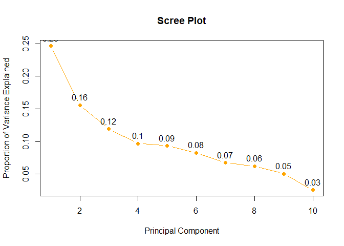

```r
# Plot Scree Plot
scree_var <- res.pca$sdev^2 / sum(res.pca$sdev^2)
scree_plot <- plot(1:length(scree_var), scree_var, type = "b",
                   xlab = "Principal Component", ylab = "Proportion of Variance Explained",
                   main = "Scree Plot", col = "orange", pch = 19)

# Add text labels for each point
text(1:length(scree_var), scree_var, labels = round(scree_var, 2), pos = 3)
```

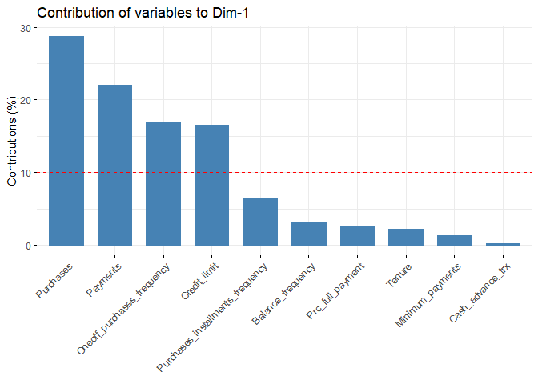

```r
# Plot Contribution of Variables on Axes 1 and 2
pca1 <- fviz_contrib(res.pca, choice = "var", axes = 1, top = 10)
print(pca1)
```

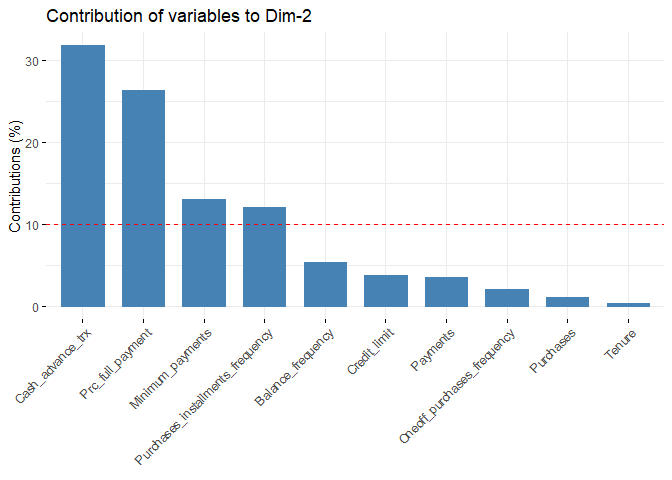

```r
pca2 <- fviz_contrib(res.pca, choice = "var", axes = 2, top = 10)
print(pca2)
```

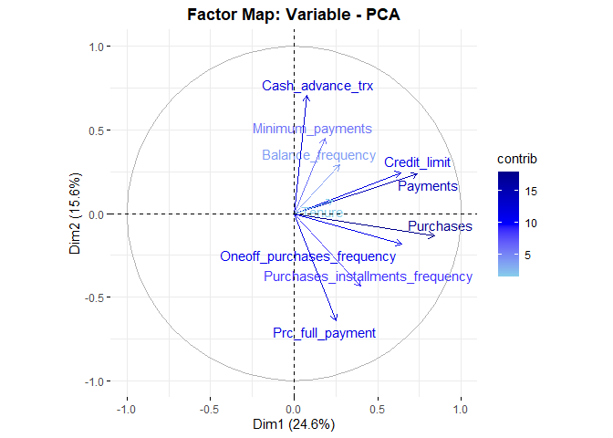

```r
# Plot Factor Map for Variables
factor_map <- fviz_pca_var(res.pca, repel = TRUE,
                            col.var = "contrib",
                            gradient.cols = c("skyblue", "blue", "darkblue")) +
  labs(title = "Factor Map: Variable - PCA") +
  theme(plot.title = element_text(hjust = 0.5, face = "bold"))
print(factor_map)
```

*Identification of Important Variables:*

- We pinpoint key variables like purchases, cash advances, payments, and credit limits. These are crucial because they have a big impact on the data and are well-represented by our first two PCA components.

*Correlation Trends Unveiled:*

PCA highlights correlation trends among variables, illustrating groupings such as:

- Positive correlation between “Purchases” and “Oneoff_purchases_frequency”.
- Positive correlation between “Credit_limit” and “Payments”.
- Positive correlation between “Cash_advance_trx” and “Minimum_payments”.
- Negative correlation between “Minimum_payments” and “Prc_full_payment”.

*Insights for Clustering - Way for Next Step:*

These detected correlations pave the way for potential insights into clustering analysis. Notable questions and hypotheses arise, including:

- Are there distinct groups of credit card holders based on their purchasing behavior?
- Do certain groups prefer minimum payments over full balance payments?
- Are there specific groups inclined towards frequent cash advances?

## 4. Clustering Analysis:

#### 4.1 Cluster-Tendency Assessment:

```r
# Cluster-Tendency Assessment
set.seed(123)
hopkins_stat <- hopkins(cc.scale, m = nrow(cc.scale) - 1)
if (hopkins_stat >= 0.7) {
  cat("The Hopkins Statistics is close to 1, indicating significant clustering tendency.\n")
} else {
  cat("The Hopkins Statistics is not indicative of significant clustering tendency.\n")
}
```

```
## The Hopkins Statistics is close to 1, indicating significant clustering tendency.
```

#### 4.2 CLARA (Clustering Large Applications):

- Given the dataset’s size, we opt for CLARA as the clustering algorithm, an extension of PAM designed for large datasets. CLARA employs a sampling approach to mitigate computational and memory constraints. We select CLARA over hierarchical clustering methods due to its scalability.
- We conduct six CLARA algorithms for varying cluster numbers (K) to explore different partitionings of the data. Visualizing these partitions helps us understand how the clusters evolve with different K values.

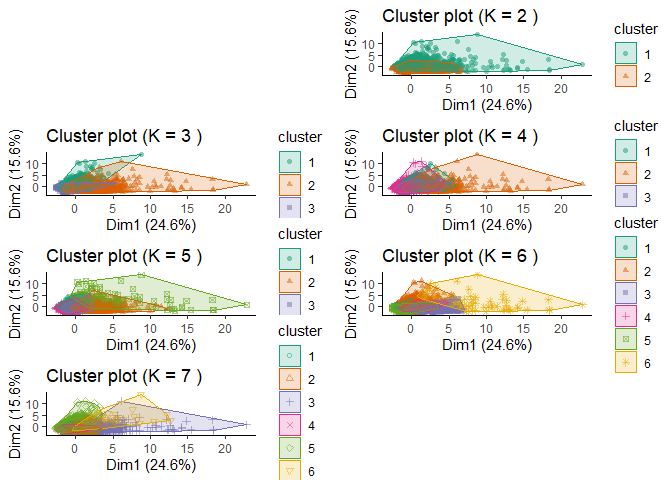

```r
# CLARA
res.clara <- list()
plot_list <- list()

for (k in 2:7) {
  # Perform CLARA clustering
  res.clara[[k]] <- eclust(cc.scale, FUNcluster = "clara", k = k, graph = FALSE)

  # Visualize CLARA Results
  plot_title <- paste("Cluster plot (K =", k, ")")
  plot_list[[k]] <- fviz_cluster(res.clara[[k]], show.clust.cent = FALSE, geom = "point",
                                 alpha = 0.5, palette = "Dark2") +
                     theme_classic() + labs(title = plot_title)
}

# Plot the results in a grid
plot_grid(plotlist = plot_list, ncol = 2)
```

- The silhouette width of each observation in each K is also examined. A high silhouette width indicates well-clustered observations, while negative values suggest potential misclassifications. These visualizations aid in determining the optimal number of clusters.

```r
# Silhouette Width Visualization
silhouette_plots <- lapply(res.clara, function(res) {
  if (!is.null(res)) {
    fviz_silhouette(res, palette = "Dark2")
  }
})
```

```
##   cluster size ave.sil.width
## 1       1 6897          0.23
## 2       2 1739          0.14
##   cluster size ave.sil.width
## 1       1 3978          0.31
## 2       2 3462          0.04
## 3       3 1196          0.25
##   cluster size ave.sil.width
## 1       1 4267          0.30
## 2       2 2574          0.07
## 3       3 1065          0.27
## 4       4  730          0.23
##   cluster size ave.sil.width
## 1       1 3699          0.29
## 2       2 1737          0.06
```

[output cut: 18 more lines]

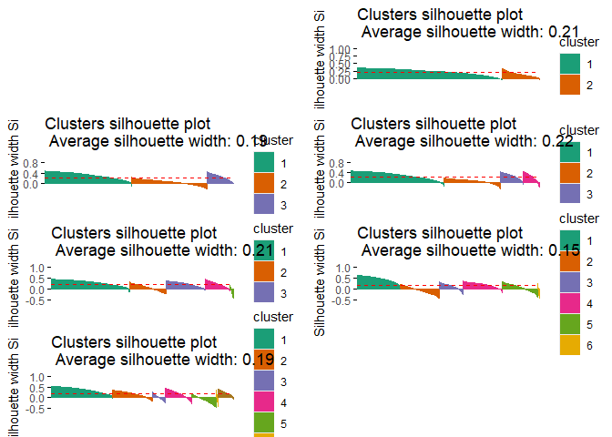

```r
plot_grid(plotlist = silhouette_plots, ncol = 2)
```

*The Elbow Method:*

- The Elbow Method helps us find the best number of clusters (k) for our data. We calculate the total within-cluster variation, known as the Total Within Sum of Squares (WSS), for different values of k. As we increase k, the WSS generally decreases. However, the optimal k is where the reduction in WSS starts to slow down significantly, forming a bend or “elbow” on the graph.
- In our analysis, the Total WSS graph suggests that the optimal k could be either 5 or 6.

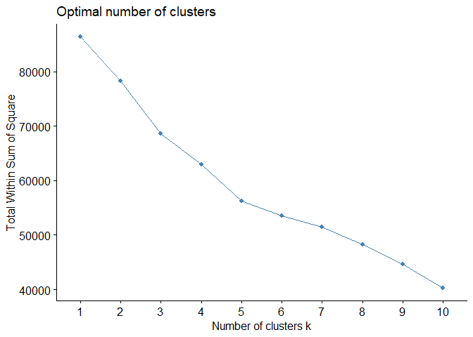

```r
fviz_nbclust(cc.scale, FUNcluster = clara, method = "wss")
```

*Silhouette Method:*

- The Silhouette Method also helps us determine the best k for clustering. It uses the average silhouette width, which represents how similar each point is to others in its cluster. A high average silhouette width indicates good clustering, as it means that points within clusters are similar to each other.
- Based on our analysis, the Silhouette Method suggests that 4 is the optimal number of clusters because it has the highest average silhouette width.

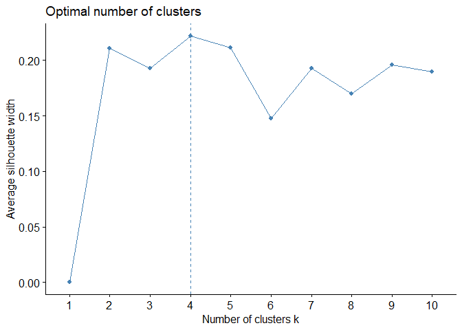

```r
fviz_nbclust(cc.scale, FUNcluster = clara, method = "silhouette")
```

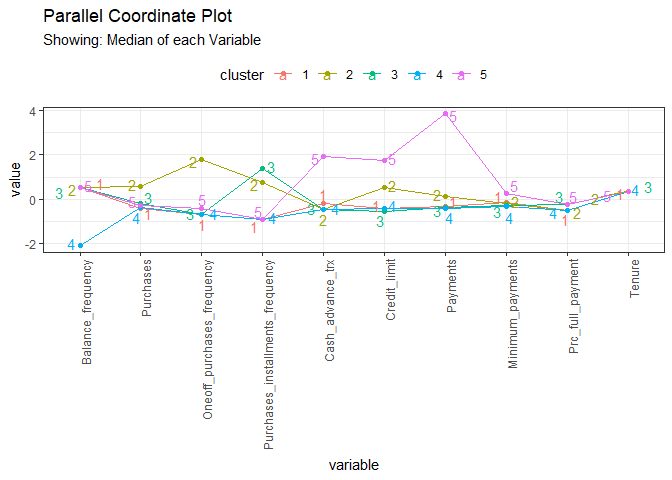

```r
# Create parallel coordinate plot
set.seed(123)

# Set up dataframe
clara_k6 <- cbind(as.data.frame(cc.scale),
                  cluster = res.clara[[5]]$clustering) %>%  # Merge scaled data with clusters
  mutate(cluster = as.factor(cluster)) %>%
  relocate(cluster, .before = Balance_frequency)

clara_k6_median <- clara_k6 %>%
                   as.data.frame() %>%
                   group_by(cluster) %>%
                   summarise_all(median)

ggparcoord(clara_k6_median,
           columns = c(2:11),
           groupColumn = "cluster",
           scale = "globalminmax",
           showPoints = TRUE) +
  theme_bw() +
  theme(axis.text.x = element_text(angle = 90, hjust = 1),
        legend.position = "top") +
  labs(title = "Parallel Coordinate Plot",
       subtitle = "Showing: Median of each Variable") +
  geom_text_repel(aes(label = cluster), box.padding = 0.1)
```

Based on this analysis, we identify five distinct groups of credit card users based on their behavior and transaction patterns. These clusters provide valuable insights into customer segmentation and can inform targeted marketing strategies or product offerings. Additionally, parallel coordinate plots visualize the median values of variables within each cluster, facilitating deeper interpretation of the cluster characteristics.